# Segmentation: Clustering

Session 1

Luis F. Gómez L.

luis.gomezl@unimilitar.edu.co

Distance Learning Faculty

19 May, 2026

# Please Read Me

- This presentation is based on (Chapman & Feit, 2019, Chapter 11)
- **Purpose**
  - Find groups of customers that differ in different dimensions to engage in more effective promotion

# Consumer segmentation survey

- **age**: age of the consumer in years
- **gender**: if the consumer is male of female
- **income**: yearly disposable income of the consumer
- **kids**: number of children of the consumer
- **ownHome**: if the consumer owns a home
- **subscribe**: if the consumer is subscribed or not
- **Import data**

```r
segmentation <- read_csv(file = "http://goo.gl/qw303p") |>
  select(-Segment) # Remove Segment column to understand how it was build
segmentation |> head(n = 5)
```

```
# A tibble: 5 × 6
    age gender income  kids ownHome subscribe
  <dbl> <chr>   <dbl> <dbl> <chr>   <chr>
1  47.3 Male   49483.     2 ownNo   subNo
2  31.4 Male   35546.     1 ownYes  subNo
3  43.2 Male   44169.     0 ownYes  subNo
4  37.3 Female 81042.     1 ownNo   subNo
5  41.0 Female 79353.     3 ownYes  subNo
```

- **Inspect data**

```r
segmentation |> glimpse()
```

```
Rows: 300
Columns: 6
$ age       <dbl> 47.31613, 31.38684, 43.20034, 37.31700, 40.95439, 43.03387, …
$ gender    <chr> "Male", "Male", "Male", "Female", "Female", "Male", "Male", …
$ income    <dbl> 49482.81, 35546.29, 44169.19, 81041.99, 79353.01, 58143.36, …
$ kids      <dbl> 2, 1, 0, 1, 3, 4, 3, 0, 1, 0, 0, 0, 2, 3, 1, 3, 0, 0, 1, 2, …
$ ownHome   <chr> "ownNo", "ownYes", "ownYes", "ownNo", "ownYes", "ownYes", "o…
$ subscribe <chr> "subNo", "subNo", "subNo", "subNo", "subNo", "subNo", "subNo…
```

- Transform data

```r
segmentation <- segmentation |>
  mutate(
    gender = factor(gender, ordered = FALSE),
    kids = as.integer(kids),
    ownHome = factor(ownHome, ordered = FALSE),
    subscribe = factor(subscribe, ordered = FALSE)
  )

segmentation |> head(n = 5)
```

```
# A tibble: 5 × 6
    age gender income  kids ownHome subscribe
  <dbl> <fct>   <dbl> <int> <fct>   <fct>
1  47.3 Male   49483.     2 ownNo   subNo
2  31.4 Male   35546.     1 ownYes  subNo
3  43.2 Male   44169.     0 ownYes  subNo
4  37.3 Female 81042.     1 ownNo   subNo
5  41.0 Female 79353.     3 ownYes  subNo
```

- **Summarize data**
  - Ups the table is really big!!! Try it in your console to see the complete table

```r
segmentation |> skim()
```

**Segmentation**

- Classification (**We will not cover this topic**)
  - Supervised learning
    - Dependent variable is known and the goal is to predict the dependent variable from the independent variables
    - Naive bayes, Random Forest
- Clustering (**This topic will be covered**)
  - Unsupervised learning
    - Dependent variable is unknown and the goal is to discover it from the independent variables
    - Model-based clustering, Latent Class Analysis (**We will not cover these methods**)
    - Hierarchical clustering, k-means (**These methods will be covered**)
- Clustering
  - Grouping a set of observations in such a way that observations in the same group (cluster) are more similar to each other than to those in other groups (clusters).
  - A notion of how **“close”** 2 observations is necessary to group objects where this is formalized using the concept of **distance** (known as metric[^1] in mathematics)
    - There are many notions of distance (Deza & Deza, 2016) where in this chapter the **Euclidean** and the **Gower** distance will be used
- **Euclidean distance**: it can only be used for numerical data
  - $x = (x_1, x_2, \ldots, x_n)$
  - $y = (y_1, y_2, \ldots, y_n)$

$$\begin{split}
d(x,y) & = \sqrt{(x_1 - y_1)^2 + (x_2 - y_2)^2 + \ldots + (x_n - y_n)^2} \\
& = \sqrt{ \sum_{k = 1}^n (x_k - y_k)^2 }
\end{split}$$

- An example:
  - 2 customers characteristic by age and income
    - $a = (45, 3500)$
    - $b = (23, 1500)$
- Manual calculation
  - $d(a,b) = \sqrt{(45 - 23)^2 + (3500 - 1500)^2} = 2000.121$

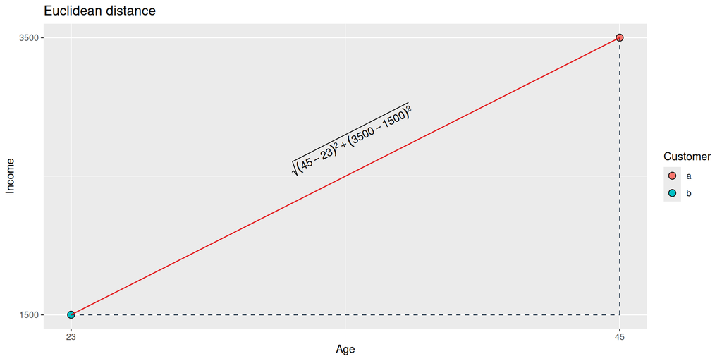

- Using R

```r
customers <- tibble(Customer = c("a", "b"),
                    Age = c(45, 23),
                    Income = c(3500, 1500))
customers
```

```
# A tibble: 2 × 3
  Customer   Age Income
  <chr>    <dbl>  <dbl>
1 a           45   3500
2 b           23   1500
```

```r
library(cluster)
customers |>
  select(-Customer) |>
  daisy(metric = "euclidean")
```

```
Dissimilarities :
         1
2 2000.121

Metric :  euclidean
Number of objects : 2
```

- **Gower distance**: it can be used for categorical, numerical data and missing values
  - $x = (x_1, x_2, \ldots, x_n)$
  - $y = (y_1, y_2, \ldots, y_n)$

$$\begin{split}
d(x,y) & = \left[ \frac{w_1\delta_{x_1y_1}^k}{\sum_{k=1}^n w_k\delta_{x_iy_i}^k}\right] d_{x_1y_1}^1 + \ldots + \left[ \frac{w_n\delta_{x_ny_n}^k}{\sum_{k=1}^n w_k\delta_{x_iy_i}^k} \right] d_{x_ny_n}^n \\
& = \frac{\sum_{k=1}^n w_k \delta_{x_iy_i}^kd_{x_iy_i}^k}{\sum_{k=1}^n w_k\delta_{x_iy_i}^k}
\end{split}$$

Where:

$$w_k \in \mathbb{R} \text{ for } k = 1, 2, \ldots, n$$

$$\sum_{k=1}^n w_k\delta_{x_iy_i}^k = w_1\delta_{x_1y_1}^1 + w_2\delta_{x_2y_2}^2 + \ldots + w_n\delta_{x_ny_n}^n$$

- **Gower distance**: it can be used for categorical, numerical data and missing values
  - $x = (x_1, x_2, \ldots, x_n)$
  - $y = (y_1, y_2, \ldots, y_n)$

$$d(x,y) = \frac{\sum_{k=1}^n w_k \delta_{x_ky_k}^kd_{x_ky_k}^k}{\sum_{k=1}^n w_k\delta_{x_ky_k}^k}$$

Where[^2]:

$$\delta_{x_ky_k}^k =
\begin{cases}
0 & \text{if } x_k \text{ or } y_k \text{ is a missing value}\\
0 & \text{if } x_k, y_k \text{ represent an asymmetric binary variable and } x_k = y_k = 0 \\
1 & \text{otherwise}
\end{cases}$$

- **Gower distance**: it can be used for categorical, numerical data and missing values
  - $x = (x_1, x_2, \ldots, x_n)$
  - $y = (y_1, y_2, \ldots, y_n)$

$$d(x,y) = \frac{\sum_{k=1}^n w_k \delta_{x_ky_k}^kd_{x_ky_k}^k}{\sum_{k=1}^n w_k\delta_{x_ky_k}^k}$$

Where:

$$d_{x_ky_k}^k =
\begin{cases}
0 & \text{if } x_k, y_k \text{ is a nominal or binary variable and } x_k = y_k \\
1 & \text{if } x_k, y_k \text{ is a nominal or binary variable and } x_k \neq y_k \\
\frac{\left| x_k - y_k \right|}{max(x_k, y_k) - min(x_k, y_k)} & \text{otherwise}
\end{cases}$$

If $x_k, y_k$ represent an ordinal variable they are replaced by their integer codes. For example if $x_k \precsim y_k$ then $1$ is assigned to $x_k$ and $2$ is assigned to $y_k$

- An example:
  - 2 customers characteristic by sex (nominal), income (numerical), satisfaction (ordinal with levels $Low \precsim Medium \precsim High$) and age (with a missing value $(NA)$)
    - $a = (Female, 3500, Medium, 45)$
    - $b = (Male, 1500, High, NA)$
- Manual calculation:
  - In R $w_k = 1$ for every $k$ as a default value where in this example $k = 1, 2, 3, 4$
  - $\sum_{k=1}^4 w_k\delta_{x_ky_k}^k = 1*1 + 1*1 + 1*1 + 1*0 = 1 + 1 + 1 + 0 = 3$
  - $\sum_{k=1}^4 w_k \delta_{x_ky_k}^kd_{x_ky_k}^k = 1*1 + 1*\frac{\left| 3500 - 1500 \right|}{3500 - 1500} + 1*\frac{\left| 2 - 3 \right|}{3 - 2} + 0 = 3$
  - $d(x,y) = \frac{\sum_{k=1}^4 w_k \delta_{x_ky_k}^kd_{x_ky_k}^k}{\sum_{k=1}^4 w_k\delta_{x_ky_k}^k} = \frac{3}{3} = 1$
- **Gower distance** range:
  - $d(x,y) \in [0,1]$
  - If $d(x,y) \longrightarrow 0$ is more similar
  - If $d(x,y) \longrightarrow 1$ is more dissimilar
- Using R

```r
customers2 <- tibble(Customer = c("a", "b"),
                     Sex = c("Female", "Male"),
                     Income = c(3500, 1500),
                     Satisfaction = c("Medium", "High"),
                     Age = c(45, NA)) |>
  mutate(Sex = factor(x = Sex,
                      ordered = FALSE),
         Satisfaction = factor(x = Satisfaction,
                               levels = c("Low", "Medium", "High"),
                               ordered = TRUE))
customers2
```

```
# A tibble: 2 × 5
  Customer Sex    Income Satisfaction   Age
  <chr>    <fct>   <dbl> <ord>        <dbl>
1 a        Female   3500 Medium          45
2 b        Male     1500 High            NA
```

- Using R

```r
customers2 |>
  select(-Customer) |>
  daisy(metric = "gower")
```

```
Dissimilarities :
  1
2 1

Metric :  mixed ;  Types = N, I, O, I
Number of objects : 2
```

- In this case:
  - `Metric: mixed` because it includes categorical and numerical data
  - For `Types = N, I, O, I` check out `?cluster::dissimilarity.object`[^3]
    - `N`: Nominal (factor)
    - `I`: Interval scaled (numeric)
    - `O`: Ordinal (ordered factor)
- Using R

```r
customers2 |>
  select(-Customer) |>
  daisy(metric = "gower")
```

```
Dissimilarities :
  1
2 1

Metric :  mixed ;  Types = N, I, O, I
Number of objects : 2
```

- In this case:
  - `Number of objects : 2`
    - There are 2 observations that correspond to customers **a** and **b**: $a = (Female, 3500, Medium, 45)$ and $b = (Male, 1500, High, NA)$
- The original dissimilarity matrix is of dimension $300 \times 300$
  - Showing only the relation between the first $5$ observations
  - The position $(i,j)$ means the dissimilarity between the observations $i$ and $j$
    - For example $(4, 3)$, which is equal to $0.425$, is the dissimilarity between the observations $4$ and $3$

```r
segmentation_dist <- segmentation |>
  daisy(metric = "gower")

segmentation_dist |>
  as.matrix() |>
  as_tibble() |>
  select(`1`:`5`) |>
  slice(1:5)
```

```
# A tibble: 5 × 5
    `1`    `2`    `3`   `4`   `5`
  <dbl>  <dbl>  <dbl> <dbl> <dbl>
1 0     0.253  0.233  0.262 0.416
2 0.253 0      0.0680 0.413 0.301
3 0.233 0.0680 0      0.425 0.293
4 0.262 0.413  0.425  0     0.227
5 0.416 0.301  0.293  0.227 0
```

```r
customers3 <- tibble(Customer = c("a", "b", "c", "d", "e"),
                     Sex = c("Female", "Male", "Female", "Female", "Male"),
                     Income = c(3500, 1500, 200, 450, 5000),
                     Satisfaction = c("Medium", "High", "Low", "Low", "Medium"),
                     Age = c(45, NA, 34, 23, 55)) |>
  mutate(Sex = factor(x = Sex,
                      ordered = FALSE),
         Satisfaction = factor(x = Satisfaction,
                               levels = c("Low", "Medium", "High"),
                               ordered = TRUE))

customers3
```

```
# A tibble: 5 × 5
  Customer Sex    Income Satisfaction   Age
  <chr>    <fct>   <dbl> <ord>        <dbl>
1 a        Female   3500 Medium          45
2 b        Male     1500 High            NA
3 c        Female    200 Low             34
4 d        Female    450 Low             23
5 e        Male     5000 Medium          55
```

- Hierarchical clustering
  - **Method**: Complete Linkage Clustering

```r
customers3_dist <- daisy(x = select(customers3, -Customer),
                        metric = "gower")

customers3_dist
```

```
Dissimilarities :
           1          2          3          4
2 0.63888889
3 0.38281250 0.75694444
4 0.45572917 0.73958333 0.09895833
5 0.40625000 0.40972222 0.78906250 0.86197917

Metric :  mixed ;  Types = N, I, O, I
Number of objects : 5
```

```r
customers3_hc <- hclust(d = customers3_dist,
                        method = "complete")

customers3_hc
```

```
Call:
hclust(d = customers3_dist, method = "complete")

Cluster method   : complete
Number of objects: 5
```

- Hierarchical clustering
  - **Method**: Complete Linkage Clustering

```r
plot(customers3_hc)
```

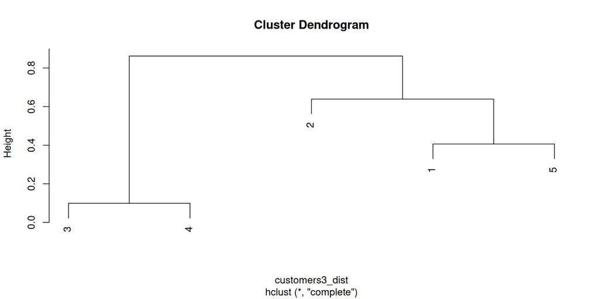

- Compare each observation and find the pair that is more similar

|  | 1 | 2 | 3 | 4 | 5 |
| --- | --- | --- | --- | --- | --- |
| 1 | 0 | 0.6388889 | 0.38281250 | 0.45572917 | 0.4062500 |
| 2 | 0.6388889 | 0 | 0.75694444 | 0.73958333 | 0.4097222 |
| 3 | 0.3828125 | 0.7569444 | 0 | 0.09895833 | 0.7890625 |
| 4 | 0.4557292 | 0.7395833 | 0.09895833 | 0 | 0.8619792 |
| 5 | 0.4062500 | 0.4097222 | 0.78906250 | 0.86197917 | 0 |

- Now we have the first cluster that includes the observations $3$ and $4$: $C(3,4)$
- Then we need to create clusters with observations $1$, $2$ and $5$ and the cluster $C(3,4)$
  - How we compare a cluster with an observation
    - **Complete Linkage Clustering**: Use the maximum distance between an observation and an observation that belongs to the cluster
- Compare each observation, including the clusters build, and find the pair that is more similar
  - In our case $1$, $2$, $5$ and $C(3,4)$
    - The distance between $1$ and $C(3,4)$ is $0.45572917$
    - The distance between $2$ and $C(3,4)$ is $0.7569444$
    - The distance between $5$ and $C(3,4)$ is $0.8619792$

|  | 1 | 2 | 3 | 4 | 5 |
| --- | --- | --- | --- | --- | --- |
| 1 | 0 | 0.6388889 | 0.38281250 | 0.45572917 | 0.4062500 |
| 2 | 0.6388889 | 0 | 0.75694444 | 0.73958333 | 0.4097222 |
| 3 | 0.3828125 | 0.7569444 | 0 | 0.09895833 | 0.7890625 |
| 4 | 0.4557292 | 0.7395833 | 0.09895833 | 0 | 0.8619792 |
| 5 | 0.4062500 | 0.4097222 | 0.78906250 | 0.86197917 | 0 |

- Now we have the second cluster that includes the observations $1$ and $5$: $C(1,5)$
- Then we need to create clusters with observation $2$ and clusters $C(3,4)$ and $C(1,5)$
  - How we compare a cluster with another cluster
    - **Complete Linkage Clustering**: Use the maximum distance between an observation that belongs to the first cluster and an observation that belongs to the second cluster
- Compare each observation, including the clusters build, and find the pair that is more similar
  - In our case $2$, $C(3,4)$ and $C(1,5)$
    - The distance between $2$ and $C(3,4)$ is $0.7569444$
    - The distance between $2$ and $C(1,5)$ is $0.6388889$

|  | 1 | 2 | 3 | 4 | 5 |
| --- | --- | --- | --- | --- | --- |
| 1 | 0 | 0.6388889 | 0.38281250 | 0.45572917 | 0.4062500 |
| 2 | 0.6388889 | 0 | 0.75694444 | 0.73958333 | 0.4097222 |
| 3 | 0.3828125 | 0.7569444 | 0 | 0.09895833 | 0.7890625 |
| 4 | 0.4557292 | 0.7395833 | 0.09895833 | 0 | 0.8619792 |
| 5 | 0.4062500 | 0.4097222 | 0.78906250 | 0.86197917 | 0 |

- Now we have the third cluster that includes the observation $2$ and the cluster $C(1,5)$: $C(2, C(1,5))$
- Then we need to create clusters with cluster $C(2, C(1,5))$ and cluster $C(3,4)$
  - This is the cluster that includes all the observations
- Compare each observation, including the clusters build, and find the pair that is more similar
  - In our case $C(3,4)$ and $C(2, C(1,5))$
    - The distance between $C(3,4)$ and $C(2, C(1,5))$ is $0.86197917$

|  | 1 | 2 | 3 | 4 | 5 |
| --- | --- | --- | --- | --- | --- |
| 1 | 0 | 0.6388889 | 0.38281250 | 0.45572917 | 0.4062500 |
| 2 | 0.6388889 | 0 | 0.75694444 | 0.73958333 | 0.4097222 |
| 3 | 0.3828125 | 0.7569444 | 0 | 0.09895833 | 0.7890625 |
| 4 | 0.4557292 | 0.7395833 | 0.09895833 | 0 | 0.8619792 |
| 5 | 0.4062500 | 0.4097222 | 0.78906250 | 0.86197917 | 0 |

- The heights of the **Cluster Dendrogram** are: $0.09895833$, $0.40625$, $0.63888889$ and $0.86197917$
- Select a number of clusters, for example: $2$ clusters

```r
plot(customers3_hc)
rect.hclust(customers3_hc, k = 2, border = "red")
```

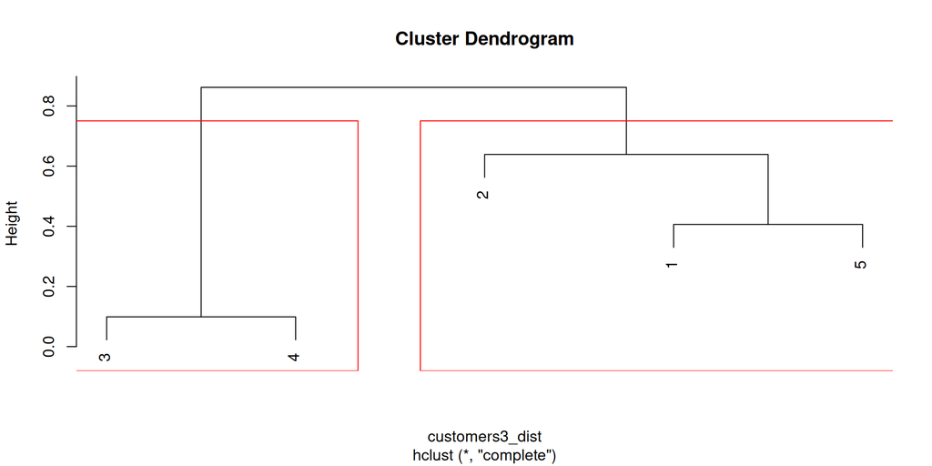

- Extract clusters and assign them to observations

```r
customers3_hc_clusters <- cutree(customers3_hc, k = 2)
customers3 |>
  mutate(cluster = customers3_hc_clusters)
```

```
# A tibble: 5 × 6
  Customer Sex    Income Satisfaction   Age cluster
  <chr>    <fct>   <dbl> <ord>        <dbl>   <int>
1 a        Female   3500 Medium          45       1
2 b        Male     1500 High            NA       1
3 c        Female    200 Low             34       2
4 d        Female    450 Low             23       2
5 e        Male     5000 Medium          55       1
```

- Select a number of clusters, using `segmentation`, for example: $4$ clusters

```r
segmentation_hc <- hclust(d = segmentation_dist,
                          method = "complete")
plot(segmentation_hc)
rect.hclust(segmentation_hc, k = 4, border = "red")
```

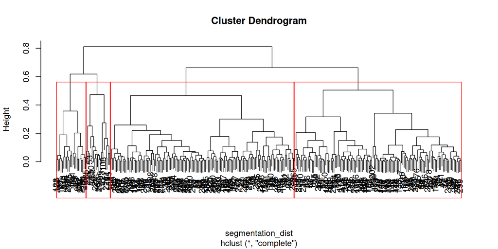

- Extract clusters and assign them to observations, using `segmentation`

```r
segmentation_hc_clusters <- cutree(segmentation_hc, k = 4)
segmentation |>
  mutate(cluster = segmentation_hc_clusters)
```

```
# A tibble: 300 × 7
     age gender income  kids ownHome subscribe cluster
   <dbl> <fct>   <dbl> <int> <fct>   <fct>       <int>
 1  47.3 Male   49483.     2 ownNo   subNo           1
 2  31.4 Male   35546.     1 ownYes  subNo           1
 3  43.2 Male   44169.     0 ownYes  subNo           1
 4  37.3 Female 81042.     1 ownNo   subNo           2
 5  41.0 Female 79353.     3 ownYes  subNo           2
 6  43.0 Male   58143.     4 ownYes  subNo           1
 7  37.6 Male   19282.     3 ownNo   subNo           1
 8  28.5 Male   47245.     0 ownNo   subNo           1
 9  44.2 Female 48333.     1 ownNo   subNo           2
10  35.2 Female 52568.     0 ownYes  subNo           2
# ℹ 290 more rows
```

- K-means clustering example (Kaufman & Rousseeuw, 1990, p. 5)

```r
kaufman_example <- tibble(name = c("Ilan", "Jacqueline", "Kim", "Lieve", "Leon", "Peter", "Talia", "Tina"),
                          weight_kg = c(15, 49, 13, 45, 85, 66, 12, 10),
                          height_cm = c(95, 156, 95, 160, 178, 176, 90, 78))

kaufman_example
```

```
# A tibble: 8 × 3
  name       weight_kg height_cm
  <chr>          <dbl>     <dbl>
1 Ilan              15        95
2 Jacqueline        49       156
3 Kim               13        95
4 Lieve             45       160
5 Leon              85       178
6 Peter             66       176
7 Talia             12        90
8 Tina              10        78
```

- K-means clustering example (Kaufman & Rousseeuw, 1990, p. 5)

```r
kaufman_example |>
  ggplot() +
  geom_point(aes(x = weight_kg, y = height_cm))
```

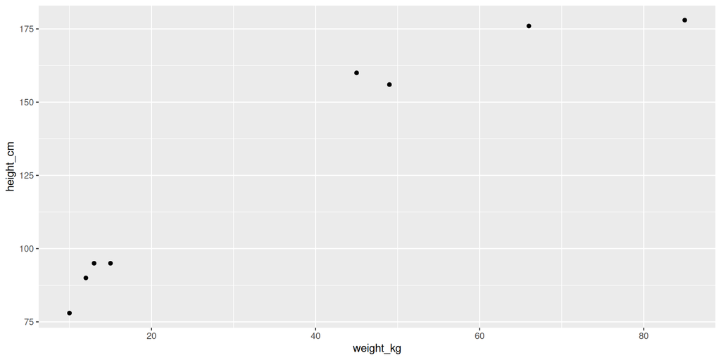

- K-means clustering example (Kaufman & Rousseeuw, 1990, p. 5)
  - Applying the [**Lloyd’s algorithm**](https://en.wikipedia.org/wiki/K-means_clustering)
    - Choose $k$ centers or the computer will choose $k$ centers at random, in our case we choose $k = 2$

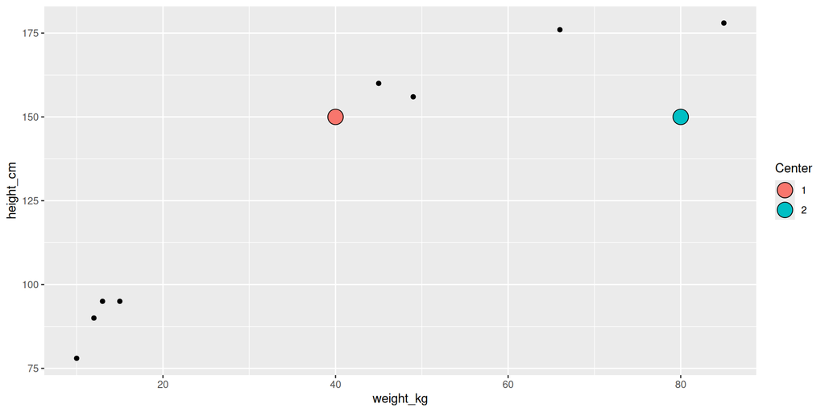

- K-means clustering example (Kaufman & Rousseeuw, 1990, p. 5)
  - Applying the [**Lloyd’s algorithm**](https://en.wikipedia.org/wiki/K-means_clustering)
    - Calculate the squared euclidean distance for each point to the $k$ centers and assign each point to the nearest center
    - For example for the point $Ilan = (15, 95)$ the distance to $Center_1 = (40, 150)$ is $(15 - 40)^2 + (95 - 150)^2 = 3650$ and the distance to $Center_2 = (80, 150)$ is $(15 - 80)^2 + (95 - 150)^2 = 7250$
    - Therefore $Ilan = (15, 95)$ is assigned to $Center_1$
- K-means clustering example (Kaufman & Rousseeuw, 1990, p. 5)
  - Applying the [**Lloyd’s algorithm**](https://en.wikipedia.org/wiki/K-means_clustering)

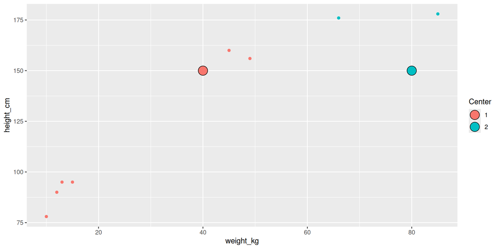

- K-means clustering example (Kaufman & Rousseeuw, 1990, p. 5)
  - Applying the [**Lloyd’s algorithm**](https://en.wikipedia.org/wiki/K-means_clustering)
    - Now calculate new centers using the assigned points by using the mean
    - For example for the new $Center_1$ the new position will be $x = \frac{15 + 49 + 13 + 45 + 12 + 10}{6} = 24$ and $y = \frac{95 + 156 + 95 + 160 + 90 + 78}{6} \approx 112.33$
    - Therefore we update as $Center_1 \approx (24, 112.33)$
- K-means clustering example (Kaufman & Rousseeuw, 1990, p. 5)
  - Applying the [**Lloyd’s algorithm**](https://en.wikipedia.org/wiki/K-means_clustering)

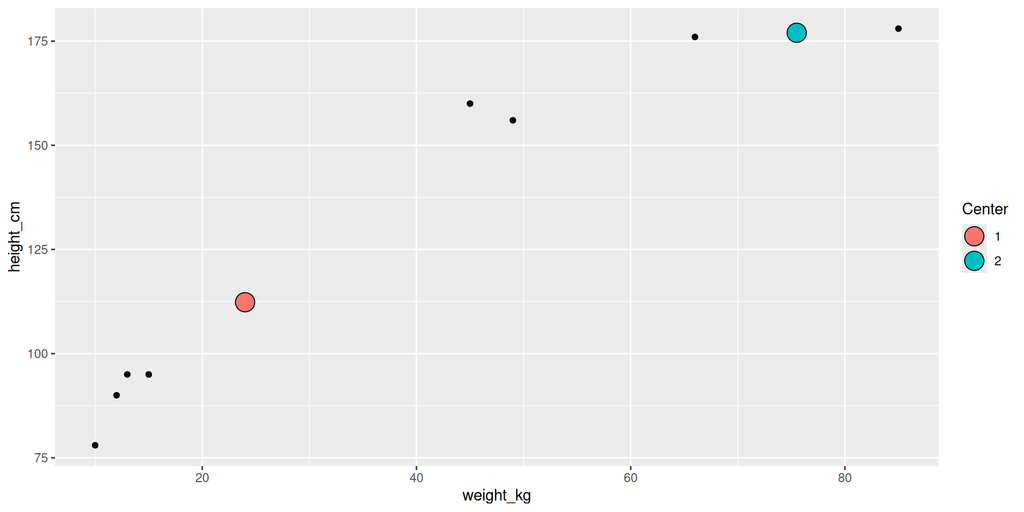

- K-means clustering example (Kaufman & Rousseeuw, 1990, p. 5)
  - Applying the [**Lloyd’s algorithm**](https://en.wikipedia.org/wiki/K-means_clustering)
  - Repeat the process by calculating the squared euclidean distance for each point to the new $k$ centers and assign each point to the nearest center

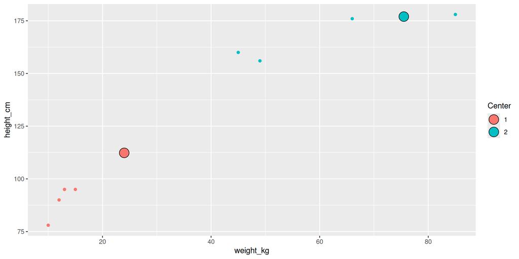

- K-means clustering example (Kaufman & Rousseeuw, 1990, p. 5)
  - Applying the [**Lloyd’s algorithm**](https://en.wikipedia.org/wiki/K-means_clustering)
  - Repeat the process until the $k$ centers don’t change and assign each point to the nearest final center

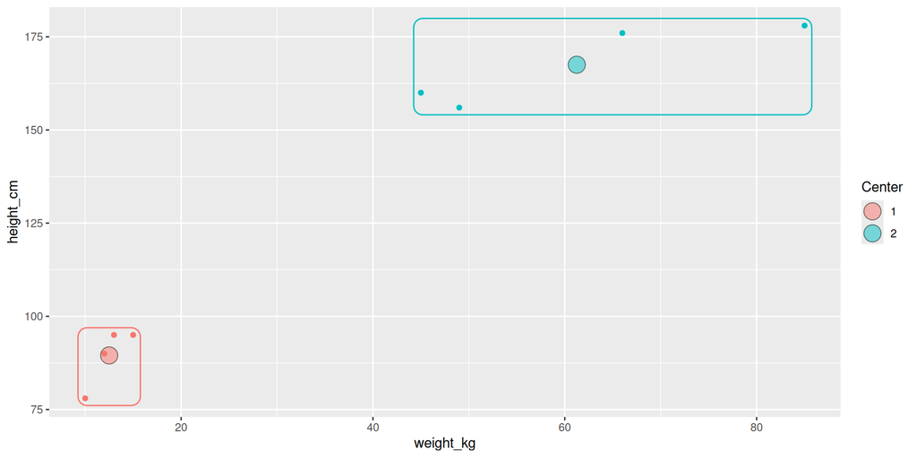

- K-means clustering example (Kaufman & Rousseeuw, 1990, p. 5)
  - Applying the [**Hartigan-Wong algorithm**](https://en.wikipedia.org/wiki/K-means_clustering)

```r
set.seed(seed = 1234) # By default R chooses at random the initial centers
                      # with set.seed we always fix the same initial centers
kaufman_example_kmeans <- kaufman_example |>
  select(weight_kg, height_cm) |>
  kmeans(centers = 2,
         algorithm = "Hartigan-Wong") # R uses this algorithm by default

kaufman_example_kmeans
```

```
K-means clustering with 2 clusters of sizes 4, 4

Cluster means:
  weight_kg height_cm
1     61.25     167.5
2     12.50      89.5

Clustering vector:
[1] 2 1 2 1 1 1 2 2

Within cluster sum of squares by cluster:
[1] 1371.75  206.00
 (between_SS / total_SS =  91.5 %)

Available components:

[1] "cluster"      "centers"      "totss"        "withinss"     "tot.withinss"
[6] "betweenss"    "size"         "iter"         "ifault"
```

- Extract clusters and assign them to observations

```r
kaufman_example_kmeans_clusters <- kaufman_example |>
  mutate(cluster = kaufman_example_kmeans$cluster)
kaufman_example_kmeans_clusters
```

```
# A tibble: 8 × 4
  name       weight_kg height_cm cluster
  <chr>          <dbl>     <dbl>   <int>
1 Ilan              15        95       2
2 Jacqueline        49       156       1
3 Kim               13        95       2
4 Lieve             45       160       1
5 Leon              85       178       1
6 Peter             66       176       1
7 Talia             12        90       2
8 Tina              10        78       2
```

- How to choose the number of clusters?

```r
library(parameters)
# Choose the optimal number of clusters
n_clusts_kaufman_example <- kaufman_example |>
  select(weight_kg, height_cm) |>
  n_clusters(
    standardize = TRUE,
    nbclust_method = "kmeans",
    n_max = 7 # We have only 8 rows
  )

# select the most parsimonious solution with fewer clusters
n_clusts_kaufman_example
```

```
# Method Agreement Procedure:

The choice of 2 clusters is supported by 4 (66.67%) methods out of 6 (Elbow, Silhouette, Gap_Maechler2012, Gap_Dudoit2002).
```

```r
# show the criterions used
n_clusts_kaufman_example |>
  as_tibble()
```

```
# A tibble: 6 × 4
  n_Clusters Method           Package   Duration
       <dbl> <chr>            <chr>        <dbl>
1          2 Elbow            easystats  0.233
2          2 Silhouette       easystats  0.0395
3          2 Gap_Maechler2012 easystats  0.109
4          2 Gap_Dudoit2002   easystats  0.104
5          6 Mixture (EEE)    mclust     0.00885
6          6 Mixture (EII)    mclust     0.00885
```

- Select a number of clusters, using `segmentation`
  - Use the package `parameters` to select the number of clusters for k-means
  - k-means only work with numerical data
  - A possible solution is to transform categorical data into numerical data
    - If a variable is nominal only works if you have 2 categories
    - If a variable is ordinal you assume that the notion of distance between them is constant or you need to specify integers to determine what distance is appropiate
    - Also you need to scale the variables taking into account that you are mixing categorical and numerical variables
- Convert binary nominal data to numerical data
  - Only make sense when you have 2 categories

```r
segmentation_numeric <- segmentation |>
  mutate(gender = as.integer(gender),
         ownHome = as.integer(ownHome),
         subscribe = as.integer(subscribe))

segmentation_numeric
```

```
# A tibble: 300 × 6
     age gender income  kids ownHome subscribe
   <dbl>  <int>  <dbl> <int>   <int>     <int>
 1  47.3      2 49483.     2       1         1
 2  31.4      2 35546.     1       2         1
 3  43.2      2 44169.     0       2         1
 4  37.3      1 81042.     1       1         1
 5  41.0      1 79353.     3       2         1
 6  43.0      2 58143.     4       2         1
 7  37.6      2 19282.     3       1         1
 8  28.5      2 47245.     0       1         1
 9  44.2      1 48333.     1       1         1
10  35.2      1 52568.     0       2         1
# ℹ 290 more rows
```

- Scale data to map each variable to a common scale
  - We are going to scale each variable to $[0,1]$
    - Use `across` and `rescale`

```r
segmentation_numeric_scale <- segmentation_numeric |>
  mutate(across(.cols = age:subscribe,
                # scales is a package that is
                # installed with the tidyverse
                # but it is not loaded automatically
                # You can use a particular function of a package using the notation
                ## <package>::<function>
                .fns = scales::rescale))

segmentation_numeric_scale |> head()
```

```
# A tibble: 6 × 6
    age gender income  kids ownHome subscribe
  <dbl>  <dbl>  <dbl> <dbl>   <dbl>     <dbl>
1 0.458      1  0.458 0.286       0         0
2 0.198      1  0.341 0.143       1         0
3 0.391      1  0.413 0           1         0
4 0.295      0  0.722 0.143       0         0
5 0.354      0  0.708 0.429       1         0
6 0.388      1  0.530 0.571       1         0
```

- Choose the numbers of clusters using the package `parameters` for k-means

```r
n_clusts_segmentation_numeric_scale <- segmentation_numeric_scale |>
  n_clusters(
    standardize = FALSE, # In this case we don't need to standardize
    nbclust_method = "kmeans",
    n_max = 10 # This is the number set by default
  )

n_clusts_segmentation_numeric_scale
```

```
# Method Agreement Procedure:

The choice of 5 clusters is supported by 7 (31.82%) methods out of 22 (kl, Ch, Hartigan, DB, Silhouette, PtBiserial, SDindex).
```

- You can check, if you want, the criteria used to select the number of clusters:

```r
n_clusts_segmentation_numeric_scale |>
  as_tibble()
```

```
# A tibble: 22 × 4
   n_Clusters Method           Package   Duration
        <dbl> <chr>            <chr>        <dbl>
 1          1 Frey             NbClust    0.0454
 2          2 Elbow            easystats  0.0461
 3          2 Duda             NbClust    0.0103
 4          2 Pseudot2         NbClust    0.00996
 5          2 Beale            NbClust    0.00993
 6          2 Mcclain          NbClust    0.0348
 7          3 Ball             NbClust    0.00837
 8          3 Mixture (VEV)    mclust     0.0779
 9          4 Gap_Maechler2012 easystats  0.470
10          4 Dunn             NbClust    0.0105
# ℹ 12 more rows
```

- Apply k-means with $k = 5$ and [**Hartigan-Wong algorithm**](https://en.wikipedia.org/wiki/K-means_clustering)
  - k-means start with $k = 5$ random centers so you need to fix this initial decision using `set.seed` if the clusters tend to change

```r
set.seed(seed = 1234)

segmentation_numeric_scale_kmeans <- segmentation_numeric_scale |>
  kmeans(centers = 5,
         algorithm = "Hartigan-Wong")

segmentation_numeric_scale_kmeans |> str()
```

```
List of 9
 $ cluster     : int [1:300] 2 3 3 4 5 3 2 2 4 5 ...
 $ centers     : num [1:5, 1:6] 0.298 0.278 0.446 0.306 0.444 ...
  ..- attr(*, "dimnames")=List of 2
  .. ..$ : chr [1:5] "1" "2" "3" "4" ...
  .. ..$ : chr [1:6] "age" "gender" "income" "kids" ...
 $ totss       : num 218
 $ withinss    : num [1:5] 7.19 17.52 14.37 5.99 7.72
 $ tot.withinss: num 52.8
 $ betweenss   : num 165
 $ size        : int [1:5] 21 78 65 71 65
 $ iter        : int 3
 $ ifault      : int 0
 - attr(*, "class")= chr "kmeans"
```

- Extract clusters and assign them to observations

```r
segmentation_kmeans_clusters <- segmentation |>
  mutate(cluster = segmentation_numeric_scale_kmeans$cluster)

segmentation_kmeans_clusters
```

```
# A tibble: 300 × 7
     age gender income  kids ownHome subscribe cluster
   <dbl> <fct>   <dbl> <int> <fct>   <fct>       <int>
 1  47.3 Male   49483.     2 ownNo   subNo           2
 2  31.4 Male   35546.     1 ownYes  subNo           3
 3  43.2 Male   44169.     0 ownYes  subNo           3
 4  37.3 Female 81042.     1 ownNo   subNo           4
 5  41.0 Female 79353.     3 ownYes  subNo           5
 6  43.0 Male   58143.     4 ownYes  subNo           3
 7  37.6 Male   19282.     3 ownNo   subNo           2
 8  28.5 Male   47245.     0 ownNo   subNo           2
 9  44.2 Female 48333.     1 ownNo   subNo           4
10  35.2 Female 52568.     0 ownYes  subNo           5
# ℹ 290 more rows
```

# Acknowledgments

- To my family that supports me
- To the taxpayers of Colombia and the [**UMNG students**](https://www.umng.edu.co/estudiante) who pay my salary
- To the [**Business Science**](https://www.business-science.io/) and [**R4DS Online Learning**](https://www.rfordatasci.com/) communities where I learn [**R**](https://www.r-project.org/about.html) and [**$\pi$-thon**](https://www.python.org/about/)
- To the [**R Core Team**](https://www.r-project.org/contributors.html), the creators of [**RStudio IDE**](https://posit.co/products/open-source/rstudio/), [**Quarto**](https://quarto.org/) and the authors and maintainers of the packages [**tidyverse**](https://CRAN.R-project.org/package=tidyverse), [**skimr**](https://CRAN.R-project.org/package=skimr), [**latex2exp**](https://CRAN.R-project.org/package=latex2exp), [**ggforce**](https://CRAN.R-project.org/package=ggforce), [**gt**](https://CRAN.R-project.org/package=gt), [**cluster**](https://CRAN.R-project.org/package=cluster) and [**tinytex**](https://CRAN.R-project.org/package=tinytex) for allowing me to access these tools without paying for a license

# References

Chapman, C., & Feit, E. M. (2019). *R For Marketing Research and Analytics* (2nd ed. 2019). Springer International Publishing : Imprint: Springer. https://doi-org.ezproxy.umng.edu.co/10.1007/978-3-030-14316-9

Deza, M. M., & Deza, E. (2016). *Encyclopedia of Distances*. Springer Berlin Heidelberg. https://doi.org/10.1007/978-3-662-52844-0

Kaufman, L., & Rousseeuw, P. J. (1990). *Finding Groups in Data: An Introduction to Cluster Analysis* (1st ed.). Wiley. https://doi.org/10.1002/9780470316801

Stevens, S. S. (1946). On the Theory of Scales of Measurement. *Science*, *103*(2684), 677–680. https://doi.org/10.1126/science.103.2684.677

## Footnotes

[^1]: https://en.wikipedia.org/wiki/Metric_space
[^2]: See (Kaufman & Rousseeuw, 1990, pp. 25–27) for a definition of **asymmetric binary variable**
[^3]: See (Stevens, 1946) and [Level of measurement](https://en.wikipedia.org/wiki/Level_of_measurement)